# Whitehead

## Whitehead's theorems

Whitehead's theorems let us deduce that spaces *are* homotopy equivalent under appropriate hypothesis in terms of algerbaic topology. These are in terms of homotopy groups, so are often used in conjunction with Hurewicz theorem.

```python
from IPython.display import Image
```

Let $(X, x_0)$ and $(Y, y_0)$ be path-connected CW complexes.

Given a map $f: (X, x_0) \to (Y, y_0)$, we get an induced map on $\pi_1$.

**Definition:** We say $Y$ is *aspherical* if $\pi_k(Y, y_0)= 0$ for all $k > 1$.

**Theorem (Whitehead):** Assume $Y$ is aspherical

1. Let $\varphi: \pi_1(X, x_0) \to \pi_1(Y, y_0)$. Then there exist $f: X \to Y$ with $f_* = \varphi$.
2. If $f, g: X \to Y$ such that $f_* = g_*: \pi_1(X, x_0) \to (Y, y_0)$, then $f \sim g$.

**Corollary:** If $X$ and $Y$ are aspherical and have the same fundamental group, then they are homotopy equivalent.

**Corollary:** If all homotopy groups of a CW complex vanish, then it is contractible.

#### Proof of Whitehead's theorem

- We construct a map $f$, or a homotopy between $f$ and $g$, inductively on skeleton's (and cells).
- The 1-skeleton is a bit subtle because the fundamental group is non-abelian.

##### Part 1

- We define on the one-skeleton directly, then extend to higher skeleta.
- The one-skeleton is a graph $\Gamma$.
- Pick a maximal tree $T \subset \Gamma$ ensuring $x_0\in T$.
- The map will take $T$ to $y_0$.
- We define on each edge $e\notin T$.

##### On the edge $e$

- The edge $e$ corresponds to an element in $\pi_1(X, x_0)$ - namely take paths to the endpoints of $e$ from $x_0$ and make a loop $\lambda$.
- We map $e$ to a loop $\mu$ at $y_0$ with $[\mu] = \varphi([\lambda])$

##### Rest of part 1:

- Observe that on the $1$-skeleton $f_* = \varphi$.
- The boundary of a $2$-cell in $X^{(2)}$ is trivial in $\pi_1(X, x_0)$ so has trivial image. Hence we can extend the map to the $2$-cell.
- Succesively extend to $X^{(3)}$, $X^{(4)}$ etc. by extending the map on cells. In each case, we use the result that maps extend from boundaries to discs if and only if the image of the boundary is trivial in the homotopy group.

#### Part 2

- We construct a homotopy between the given maps.
- Once more, we will construct it on the tree, and then extend over edges.
- Finally, we can easily extend over higher skeleta.

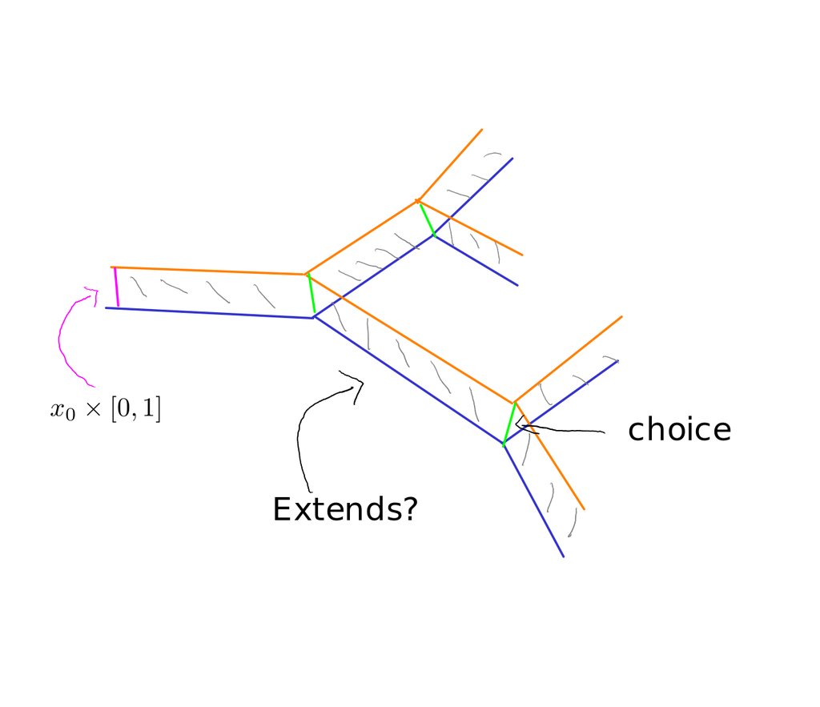

```python
Image("tree-homotopy.png")
```

We define the homotopy on $X^{(0)} \times [0, 1]$ as follows:

- Given a vertex $v$, there is a unique reduced path $\alpha$ in the tree $T$ from $x_0$ to $v$.
- Map $v \times [0, 1]$ to $f_*(\bar\alpha) * g_*(\alpha)$.
- By the choice of the map on vertical curves, we see that we have an extension to $T \times [0, 1]$.
- We can extend it to $e\times [0,1]$ for $e\notin T$ using that $f_* = g_*$.
- Finally, we can extend it to higher skeleta.

#### Another theorem of Whitehead

We no longer assume aspherical but assume that spaces are CW-complexes.

**Theorem:** If $f: X \to Y$ induces isomorphisms on all homotopy groups, then $f$ is a homotopy equivalence.

## Homology of groups (starting with Hopf)

- Suppose $G$ is a group and $X$ is an aspherical CW complex with fundamental group $G$.
- Then $X$ is unique up to homotopy.
- Hence, $H_*(X)$ is a property of $G$, which we call $H_*(G)$.
- Such an $X$ always exists, e.g. by Milnor's *Universal Join* construction.

##### Universal join

- The join of spaces is $X * Y = X \times Y \times [0, 1]/ \sim$ where $\sim$ is generated by $(x, y, 0) \sim (x, y', 0)$ and $(x, y, 1)\sim (x', y, 1)$.
- The universal join is $EG = G * G * G * \dots$ - formally the direct limit.
- $EG$ is contractible as all its homotopy groups vanish.
- We take $X = BG = EG/G$.

**Question:** How do we define $H_*(G)$ in terms of $G$ directly/algebraically?

#### Algebraic properties of classifying spaces

- For each $k$, $C_k(\tilde X)$ is a *free* $\mathbb{Z}[G]$ module (in cellular homology) with basis cells of $X$.
- The chain complex $C_*(\tilde X)$ is exact.
- We can augment this chain complex to get $$\dots \to C_2(\tilde X)\to C_1(\tilde X) \to C_0(\tilde X) \to \mathbb{Z}$$
- The chain complex $C_*(X)$ is $C_*(\tilde X)\otimes_{\mathbb{Z}[G]} \mathbb {Z}$

#### Free resolutions

- Let $R$ be a ring and $M, N$ modules over $R$.
- A *free resolution* of $M$ is an exact sequence of free $R$-modules $\dots\to F_2\to F_1 \to F_0 \to M$.
- Such a free resolution is unique up to chain homotopy.
- We define $H_*(M, N)$ as the homology of the chain complex $F_*\otimes_R N$.